# Analysis - Daims Nitrospira 4 GWW assembly

Mads Albertsen

November 24, 2015

## Introduction

This report documents the binning of a Nitrospira genome from the GWW sample. See [Daims et al., 2015: Complete Nitrification by Nitrospira Bacteria](https://doi.org/10.1038/nature16461) for further details.

## Load the mmgenome package

The metagenome data is analysed using the [mmgenome package](http://madsalbertsen.github.io/mmgenome/).

```r
library("mmgenome")
```

## Import data

The Rmarkdown file [Load_data.Rmd](http://madsalbertsen.github.io/mmgenome/Daims_GWW_Load_data.html) describes the loading of the data and can be imported using the `mmimport` function. However, the preprocessed data can also be downloaded directly from figshare: [Daims_GWW](http://dx.doi.org/10.6084/m9.figshare.1613284). Hence, here we import the prepocessed data from figshare instead.

```r
load("Daims_GWW.RData")
```

## Extract Nitrospira 4

As seen from the overview plots, there are numerous Nitrospira species. This Nitrospira seem to be relatively easy seperated from other genomes.

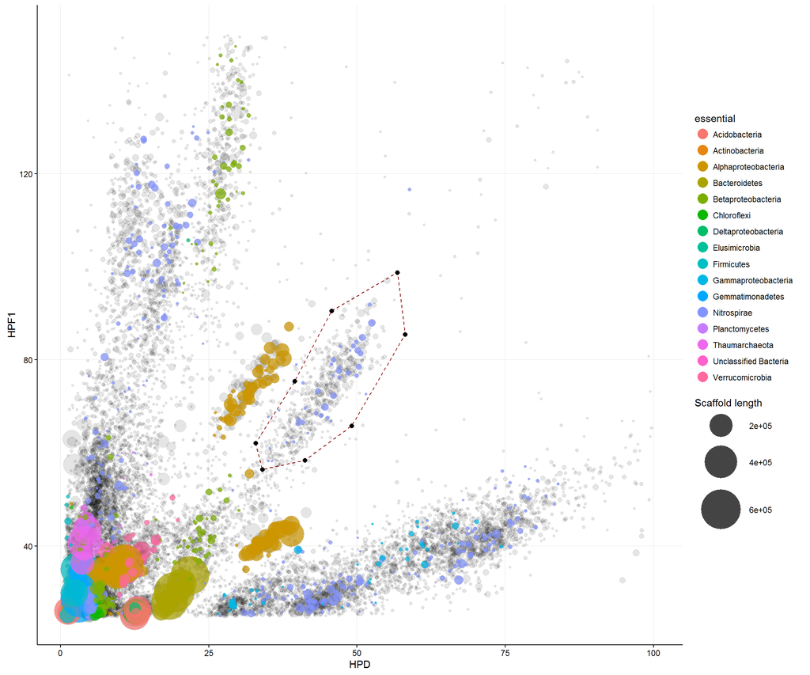

```r
p <- mmplot(data = d,
            x = "HPD",
            y = "HPF1",
            log.x = T,
            log.y = T,
            color = "essential",
            minlength = 1000,
            factor.shape = "solid") +
  xlim(1, 100) +
  ylim(25, 150)

#p
#sel <- mmplot_locator(p)

sel <- data.frame(HPD  =  c(32.9, 34, 41.2, 49.1, 58.1, 56.8, 45.7, 39.5),
                  HPF1  =  c(62.1, 56.5, 58.4, 65.8, 85.5, 98.8, 90.5, 75.4))

mmplot_selection(p, sel)
```

The scaffolds included in the defined subspace are extracted using the `mmextract` function.

```r
dA <- mmextract(d, sel)
```

The `mmstats` function applies to any extracted object. Hence, it can be used directly on the subset.

```r
mmstats(dA, ncov = 2)
```

```
##               General Stats
## n.scaffolds          537.00
## GC.mean               55.80
## N50                 6542.00
## Length.total     2445522.00
## Length.max         35221.00
## Length.mean         4554.00
## Coverage.HPD          44.91
## Coverage.HPF1         74.16
## Ess.total             74.00
## Ess.unique            73.00
```

## Using PE reads (Subset B)

```r
dB <- mmextract_network(subset = dA,
                        original = d,
                        network = pe,
                        nconnections = 1,
                        type = "direct")
```

## Clean-up other species (Subset C)

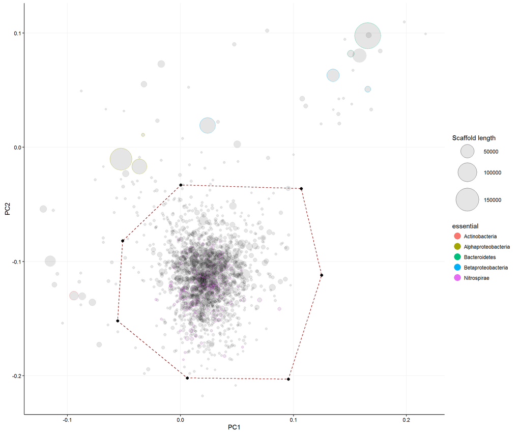

```r
p <- mmplot(data = dB,
            x = "PC1",
            y = "PC2",
            color = "essential",
            minlength = 1000)
#p
#sel <- mmplot_locator(p)

sel <- data.frame(PC1  =  c(-0.0513, -0.0556, 0.00595, 0.0954, 0.125, 0.107, 0.000222),
                  PC2  =  c(-0.0819, -0.152, -0.202, -0.203, -0.112, -0.0362, -0.0329))

mmplot_selection(p, sel)
```

The scaffolds included in the defined subspace are extracted using the `mmextract` function.

```r
dC <- mmextract(dB, sel)
```

The `mmstats` function applies to any extracted object. Hence, it can be used directly on the subset.

```r
mmstats(dC, ncov = 2)
```

```
##               General Stats
## n.scaffolds         1585.00
## GC.mean               55.70
## N50                 5807.00
## Length.total     6225312.00
## Length.max        176346.00
## Length.mean         3927.60
## Coverage.HPD          27.13
## Coverage.HPF1         60.34
## Ess.total            202.00
## Ess.unique            99.00
```

## Clean-up other Nitropira (Subset D)

We do a another selection to remove other Nitrospira scaffolds that were included.

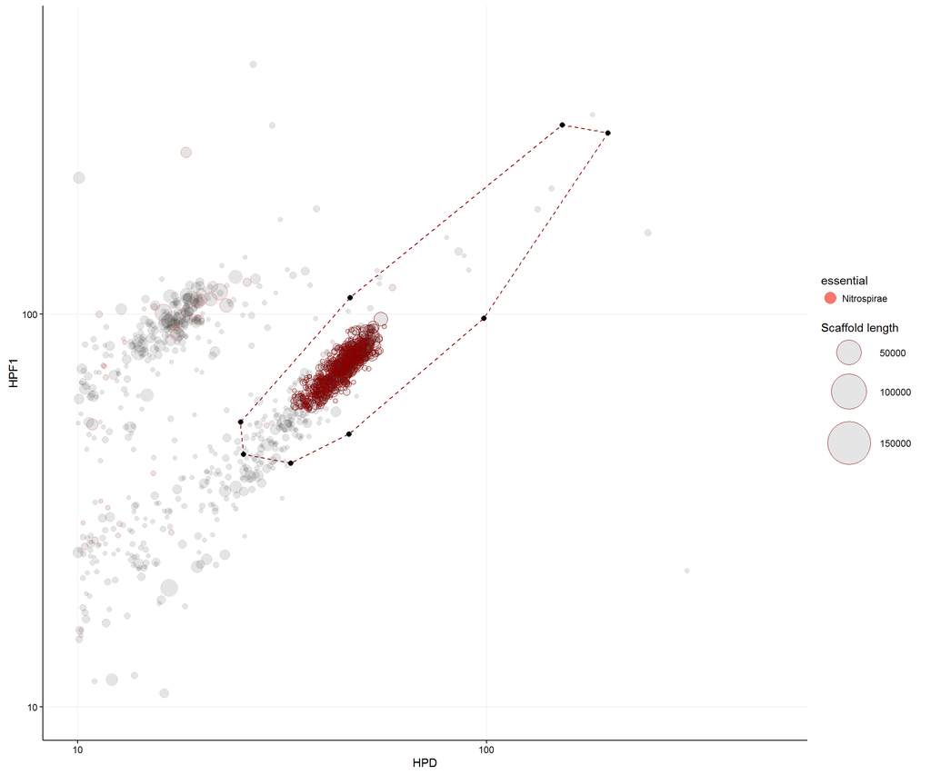

```r
p <- mmplot(data = dC,
            x = "HPD",
            y = "HPF1",
            log.x = T,
            log.y = T,
            color = "essential",
            minlength = 1000,
            highlight = dA) +
  scale_x_log10(limits=c(10,500)) +
  scale_y_log10(limits=c(10,500))

#p
#sel <- mmplot_locator(p)

sel <- data.frame(HPD  =  c(25.4, 25, 46.3, 153, 198, 98.3, 46, 33.2),
                  HPF1  =  c(44, 53.1, 110, 303, 289, 97.6, 49.5, 41.8))

mmplot_selection(p, sel)
```

The scaffolds included in the defined subspace are extracted using the `mmextract` function.

```r
dD <- mmextract(dC, sel)
```

The `mmstats` function applies to any extracted object. Hence, it can be used directly on the subset.

```r
mmstats(dD, ncov = 2)
```

```
##               General Stats
## n.scaffolds          637.00
## GC.mean               55.80
## N50                 6223.00
## Length.total     2706790.00
## Length.max         35221.00
## Length.mean         4249.30
## Coverage.HPD          44.11
## Coverage.HPF1         72.84
## Ess.total             83.00
## Ess.unique            82.00
```

## Export the scaffolds

Finally the binned scaffolds are exported.

```r
mmexport(data = dD, assembly = assembly, file = "GWW_Nitrospira4.fa")
```